# sr_chapter_1_notes

Joseph Bulbulia

01/12/2020

# Highlights from Chapter 1 in Statistical Rethinking

A few key points in Statistical Rethinking Chapter 1

## Golems and Bayes

- RM points out that statistical tests are “golems” – little robots – that will destroy your life, and Prague.
- These robots work well in some settings, but they are fragile. They fail in spectacular ways.
- Bayesian data analysis is a golem. However, it has many advantages, one of which is recovering intuitive probabilities.

## Statitical Models, Process Models, and Hypotheses

- Models: how does the world work, e.g. a process model of evolution
- Hypotheses: predictions that models make on observations:
- Statistical model: evaluation of a hypothesis: do these observations make a model more probable?
- It is not just statistical tests that may go wrong:
  - need to understand the relationship between a process model and its observations
  - need to evaluate (and re-evaluate) a statistical model (Note, a hypotheses might be continuous)
  - measurement matters

Storm clouds on the horizon: causal inference requires causal models: we need to be careful about what we include in our regressions: confounds are lurking.

Key tools at our disposal:

1. Bayesian data analysis
2. Model comparison
3. Multilevel models
4. Graphical causal models

# Questions

- What does RM think is wrong about classical statistical instruction?
- What does RM think is OK about classical statistical instruction?
- What is the advantage of Bayesian data analysis
- How do multilevel models deal with variation.

# Practicalities (not in the book)

```
## 'data.frame':    50 obs. of  2 variables:
##  $ speed: num  4 4 7 7 8 9 10 10 10 11 ...
##  $ dist : num  2 10 4 22 16 10 18 26 34 17 ...
```

```
##   speed dist
## 1     4    2
## 2     4   10
## 3     7    4
## 4     7   22
## 5     8   16
## 6     9   10
```

```
##
## Call:
## lm(formula = dist ~ speed, data = cars)
##
## Residuals:
##     Min      1Q  Median      3Q     Max
## -29.069  -9.525  -2.272   9.215  43.201
##
## Coefficients:
##             Estimate Std. Error t value Pr(>|t|)
## (Intercept) -17.5791     6.7584  -2.601   0.0123 *
## speed         3.9324     0.4155   9.464 1.49e-12 ***
## ---
## Signif. codes:  0 '***' 0.001 '**' 0.01 '*' 0.05 '.' 0.1 ' ' 1
##
## Residual standard error: 15.38 on 48 degrees of freedom
## Multiple R-squared:  0.6511, Adjusted R-squared:  0.6438
## F-statistic: 89.57 on 1 and 48 DF,  p-value: 1.49e-12
```

Let’s obtain some extra packages that will make reporting useful for you.

```
## #refugeeswelcome
```

Here’s a nicely formatted table

|  | dist |  |  |
| --- | --- | --- | --- |
| Predictors | Estimates | CI | p |
| (Intercept) | -17.58 | -31.17 – -3.99 | **0.012** |
| speed | 3.93 | 3.10 – 4.77 | **<0.001** |
| Observations | 50 |  |  |
| R<sup>2</sup> / R<sup>2</sup> adjusted | 0.651 / 0.644 |  |  |

Here’s a coefficient plot for the model, notice how I have customised it

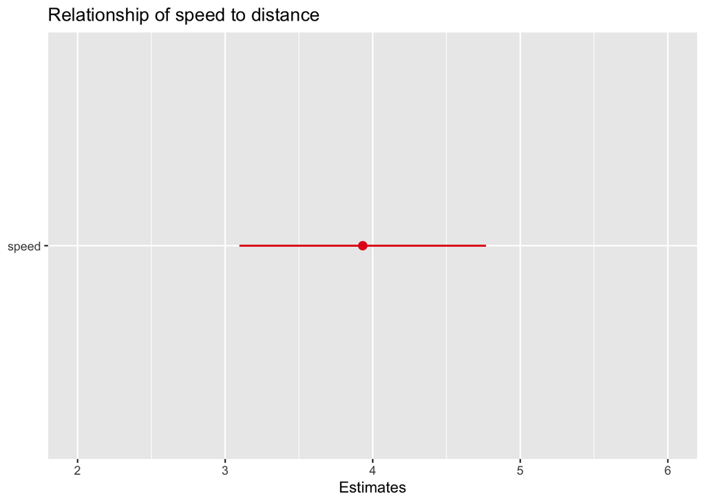

Here’s a prediction plot

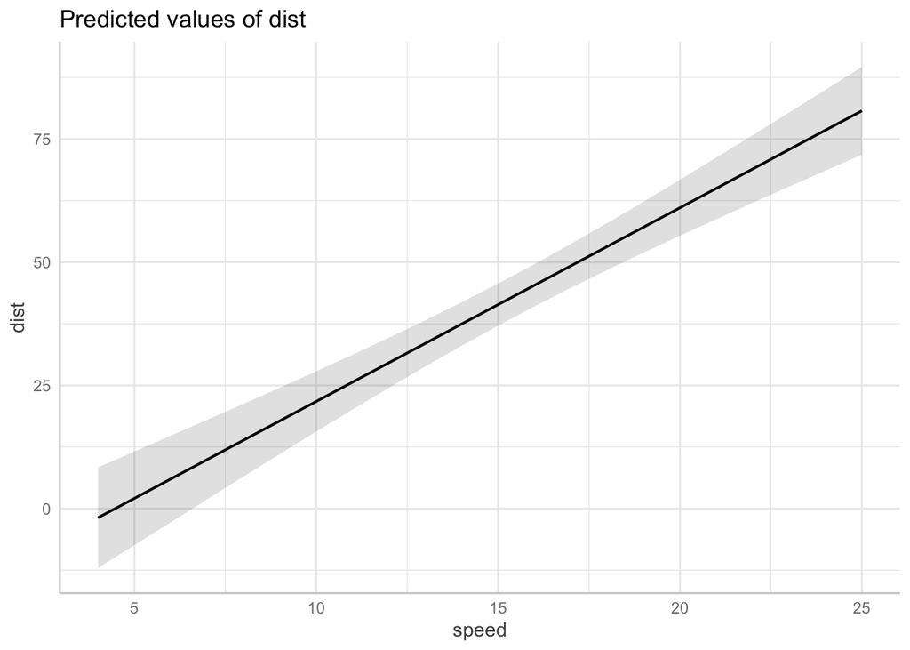

# Code for installing the rethinking package

```
##    coda    plyr mvtnorm  scales dagitty
##    TRUE    TRUE    TRUE    TRUE    TRUE
```

```
## rstan (Version 2.21.2, GitRev: 2e1f913d3ca3)
```

[output not shown]

```
## rethinking (Version 2.13)
```